# ANOVA

Pai

2023-05-07

## ANOVA ONE WAY

```r
# install.packages(c("ggpubr", "broom", "AICcmodavg"))
library(ggplot2)
library(ggpubr)
library(tidyverse)
library(broom)
library(AICcmodavg)
```

```r
# install.packages("palmerpenguins")
library(palmerpenguins)
library(tidyverse)

dat <- penguins %>%
  select(species, flipper_length_mm)
summary(dat)
```

```
##       species    flipper_length_mm
##  Adelie   :152   Min.   :172.0
##  Chinstrap: 68   1st Qu.:190.0
##  Gentoo   :124   Median :197.0
##                  Mean   :200.9
##                  3rd Qu.:213.0
##                  Max.   :231.0
##                  NA's   :2
```

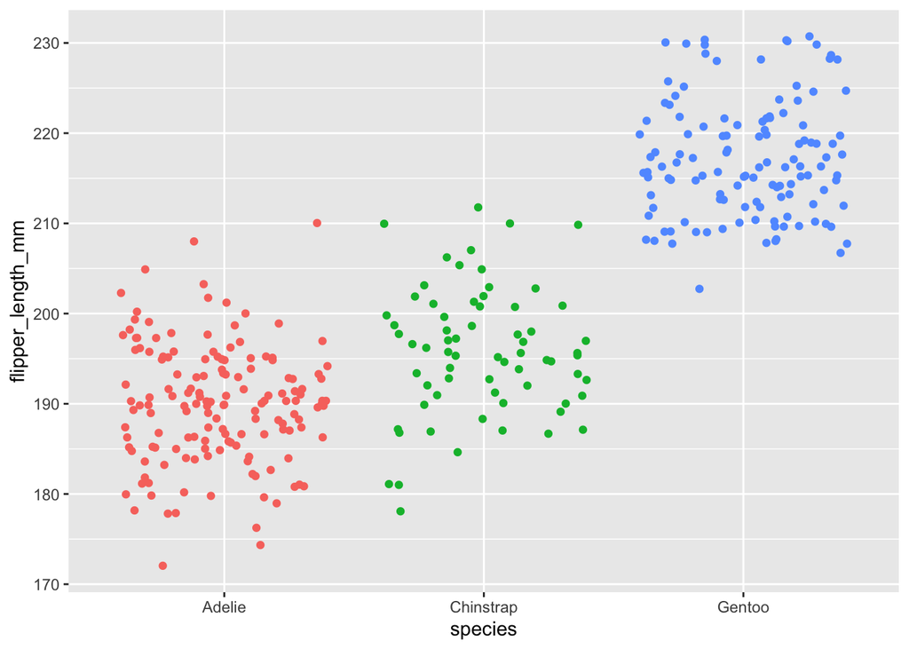

```r
library(ggplot2)

ggplot(dat) +
  aes(x = species, y = flipper_length_mm, color = species) +
  geom_jitter() +
  theme(legend.position = "none")
```

The null and alternative hypothesis of an ANOVA are:

- $H_0: \mu_{Adelie}=\mu_{Chinstrap}=\mu_{Gentoo}$ (the 3 species are equal in terms of flipper length).
- $H_1:$ *at least* one mean is different (at least one species is different from the other 2 species in terms of flipper length).

  ```r
  res_aov <- aov(flipper_length_mm ~ species,
    data = dat
  )
  summary(res_aov)
  ```

  ```
  ##              Df Sum Sq Mean Sq F value Pr(>F)
  ## species       2  52473   26237   594.8 <2e-16 ***
  ## Residuals   339  14953      44
  ## ---
  ## Signif. codes:  0 '***' 0.001 '**' 0.01 '*' 0.05 '.' 0.1 ' ' 1
  ## 2 observations deleted due to missingness
  ```

  ```r
  oneway.test(flipper_length_mm ~ species,
    data = dat,
    var.equal = TRUE # assuming equal variances
  )
  ```

  ```
  ##
  ##  One-way analysis of means
  ##
  ## data:  flipper_length_mm and species
  ## F = 594.8, num df = 2, denom df = 339, p-value < 2.2e-16
  ```

**Bài tập.** Dữ liệu về cách cho điểm môn Xác suất thống kê của 3 giáo viên như sau (điểm trên thang 100). Hãy cho biết cách chấm điểm của 3 giáo viên có sai khác nhau không?

$H_0:$ Cách chấm điểm của 3 giáo viên không sai khác nhau

| TT | A | B | C |
| --- | --- | --- | --- |
| 1 | 82 | 74 | 79 |
| 2 | 86 | 82 | 79 |
| 3 | 79 | 78 | 77 |
| 4 | 83 | 75 | 78 |
| 5 | 85 | 76 | 82 |
| 6 | 84 | 77 | 79 |

$H_1:$ Cách chấm điểm của 3 giáo viên có sai khác nhau

Khi đó t sẽ đưa bài toán trở thành bài toán kiểm định giá trị trung bình các nhóm như sau  
$H_0: \mu_1=\mu_2=\mu_3$ với $\mu_i$ là điểm thi trung bình lớp xác suất thống kê của giáo viên $i$.

$H_1:$ ngược lại.

```r
giaovien <- c("A","A","A","A","A","A","B","B","B","B","B","B","C","C","C","C","C","C")
diem <- c(82,86,79,83,85,84,74,82,78,75,76,77,79,79,77,78,82,79)
giaovien<-as.factor(giaovien)
analysis<-aov(diem~giaovien)
summary(analysis)
```

```
##             Df Sum Sq Mean Sq F value  Pr(>F)
## giaovien     2 118.78   59.39    10.5 0.00141 **
## Residuals   15  84.83    5.66
## ---
## Signif. codes:  0 '***' 0.001 '**' 0.01 '*' 0.05 '.' 0.1 ' ' 1
```

## ANOVA TWO WAY

**Ví dụ.** Sử dụng kết quả phân tích phương sai so sánh giá bán đậu tương qua các năm và giữa các tỉnh trong bảng số liệu sau (đơn vị: đồng/kg)

[output not shown]

```r
province <- c("SonLa","SonLa","HaTay", "HaTay",
"DacLak", "DacLak", "DongNai", "DongNai")
year <- c(2003, 2004, 2003, 2004, 2003, 2004, 2003,
2004)
price <- c(4440, 4247.7, 4850, 4294.3, 4400, 4284.3,
4500, 4314.3)
year <- as.factor(year)
data.frame(province,year,price)
```

```
##   province year  price
## 1    SonLa 2003 4440.0
## 2    SonLa 2004 4247.7
## 3    HaTay 2003 4850.0
## 4    HaTay 2004 4294.3
## 5   DacLak 2003 4400.0
## 6   DacLak 2004 4284.3
## 7  DongNai 2003 4500.0
## 8  DongNai 2004 4314.3
```

```r
price.anova<-aov(price~province+year)
summary(price.anova)
```

```
##             Df Sum Sq Mean Sq F value Pr(>F)
## province     3  70240   23413   1.187 0.4456
## year         1 137655  137655   6.979 0.0775 .
## Residuals    3  59171   19724
## ---
## Signif. codes:  0 '***' 0.001 '**' 0.01 '*' 0.05 '.' 0.1 ' ' 1
```